# Basic Reproduction Number and Epidemic Threshold

NodeBasedModels.jl Vignette 07 (pairwise R₀ and threshold)

Author

Simon Frost

Published

May 16, 2026

## Introduction

The basic reproduction number $R_0$ for the pair-approximation SIR on a homogeneous unclustered $n$-regular network is

$$R_0 = \frac{\tau (n-2)}{\gamma}.$$

The “$n-2$” — rather than $n-1$ as in the mean-field — accounts for the fact that the *infector* of a newly infected node is itself one of its $n$ neighbours, so only $n-1$ neighbours are at risk, *and* one of those is excluded by the pair-approximation excess-degree correction $\kappa = (n-1)/n$. The factor reduces to $n-2$ when the leading order of the next-generation matrix is computed.

Clustering reduces $R_0$ further; the package implements approximate corrections for Keeling and Barnard closures.

## Setup

```julia
using NodeBasedModels
using Plots
```

## Numerical $R_0$

```julia
net = regular_network(6)
R0_b = basic_reproduction_number(net, BernoulliClosure(), 0.125, 0.25)
println("Bernoulli, n=6, τ=0.125, γ=0.25 → R₀ = ", R0_b)

net_cl = regular_network(6; ϕ = 0.4)
R0_k = basic_reproduction_number(net_cl, KeelingClosure(), 0.125, 0.25)
println("Keeling,   n=6, ϕ=0.4 → R₀ = ", round(R0_k; digits=3))
```

```
Bernoulli, n=6, τ=0.125, γ=0.25 → R₀ = 2.0
Keeling,   n=6, ϕ=0.4 → R₀ = 1.68
```

## Symbolic $R_0$

```julia
R0_sym = basic_reproduction_number(sir_model(), net, BernoulliClosure())
println("Symbolic R₀ = ", R0_sym)
```

```
Symbolic R₀ = (4τ) / γ
```

## Threshold sweep

We sweep $\tau$ and record the final epidemic size:

```julia
function final_R(τ_val; γ_val = 0.25, n = 6, T = 400.0)
    net = regular_network(n)
    psys = generate_pairwise(sir_model(), net, BernoulliClosure();
                             tspan = (0.0, T), N = 1.0, seed_fraction = 0.01)
    p = copy(psys.params); p[:τ] = τ_val; p[:γ] = γ_val
    sol  = solve_pairwise(psys, p; reltol = 1e-8, abstol = 1e-10)
    return sol[psys.singles[:R]][end]
end

τgrid = range(0.01, 0.25; length=40)
R∞    = [final_R(τ) for τ in τgrid]
R0    = [τ * 4 / 0.25 for τ in τgrid]   # n=6 → n-2 = 4, γ = 0.25
nothing
```

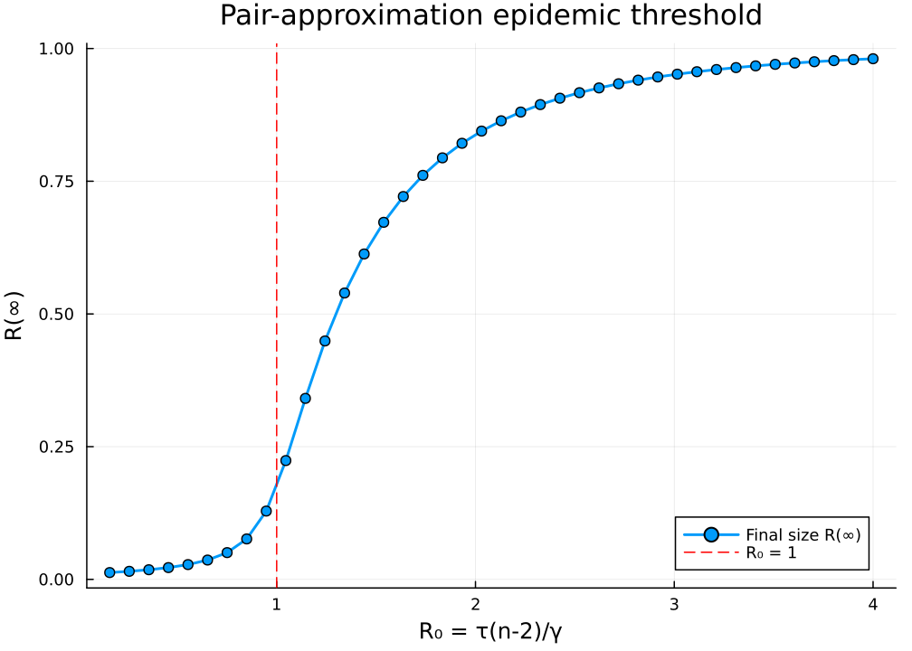

```julia
plot(R0, R∞, lw = 2, marker = :circle, label = "Final size R(∞)")
vline!([1.0], ls = :dash, color = :red, label = "R₀ = 1")
xlabel!("R₀ = τ(n-2)/γ"); ylabel!("R(∞)")
title!("Pair-approximation epidemic threshold")
```

## Early growth

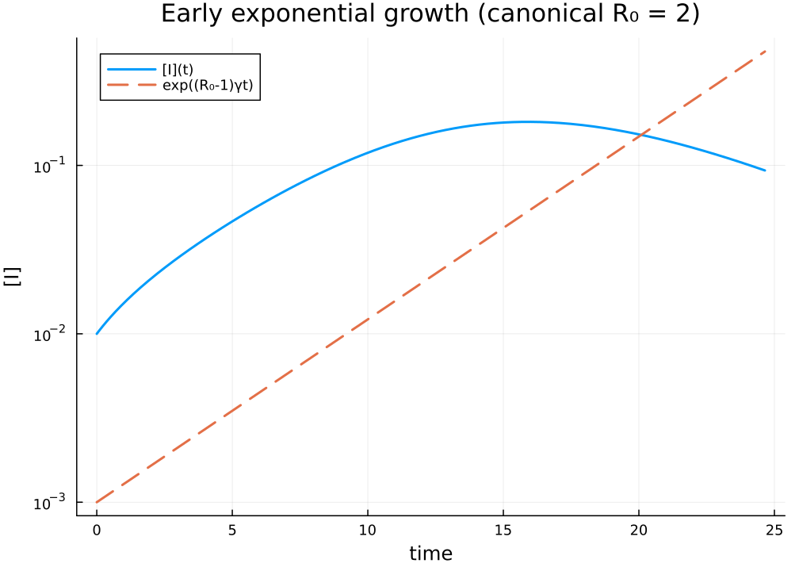

```julia
net = regular_network(6)
psys = generate_pairwise(sir_model(), net, BernoulliClosure();
                          tspan = (0.0, 40.0), N = 1.0, seed_fraction = 0.01)
I0 = 0.001
p = copy(psys.params); p[:τ] = 0.125; p[:γ] = 0.25
sol  = solve_pairwise(psys, p; reltol = 1e-10, abstol = 1e-12)

t_early = sol.t[sol.t .< 25]
I_early = sol[psys.singles[:I]][1:length(t_early)]

plot(t_early, I_early, yscale = :log10, lw = 2, label = "[I](t)")
plot!(t_early, I0 .* exp.((2.0 - 1.0) * 0.25 .* t_early),
      lw = 2, ls = :dash, label = "exp((R₀-1)γt)")
xlabel!("time"); ylabel!("[I]")
title!("Early exponential growth (canonical R₀ = 2)")
```

## Summary

`basic_reproduction_number` returns numeric or symbolic $R_0$ for any model–network–closure triple; the threshold $R_0 = 1$ separates die-out from outbreak in the pair system.

## Simulation validation

We validate the pair-approximation against Gillespie SSA on 6-regular graphs ($N = 1000$) at $\tau = 1/6$, $\gamma = 0.25$ (giving $R_0 = (k-1)T = 2$ where $T = \tau/(\tau+\gamma)$).

```julia
include("../_validation.jl")

N_v = 1000
τ_v = 1/6
γ_v = 0.25

# Re-solve PA at the validation τ
psys_v = generate_pairwise(sir_model(), regular_network(6), BernoulliClosure();
                            tspan = (0.0, 40.0), N = 1.0, seed_fraction = 0.01)
p_v = copy(psys_v.params); p_v[:τ] = τ_v; p_v[:γ] = γ_v
sol_v = solve_pairwise(psys_v, p_v; reltol = 1e-8, abstol = 1e-10)

prog_no = sir_model(τ = :β)
t_no, μ_no, σ_no = gillespie_ribbon(prog_no,
    Dict(:β => τ_v, :γ => γ_v),
    regular_graph_builder(N_v, 6);
    N = N_v, n_graphs = 5, nsims_per_graph = 40,
    tspan = (0.0, 40.0), seed_fraction = 0.01,
    tgrid = collect(0.0:0.5:40.0))
```

[output not shown]

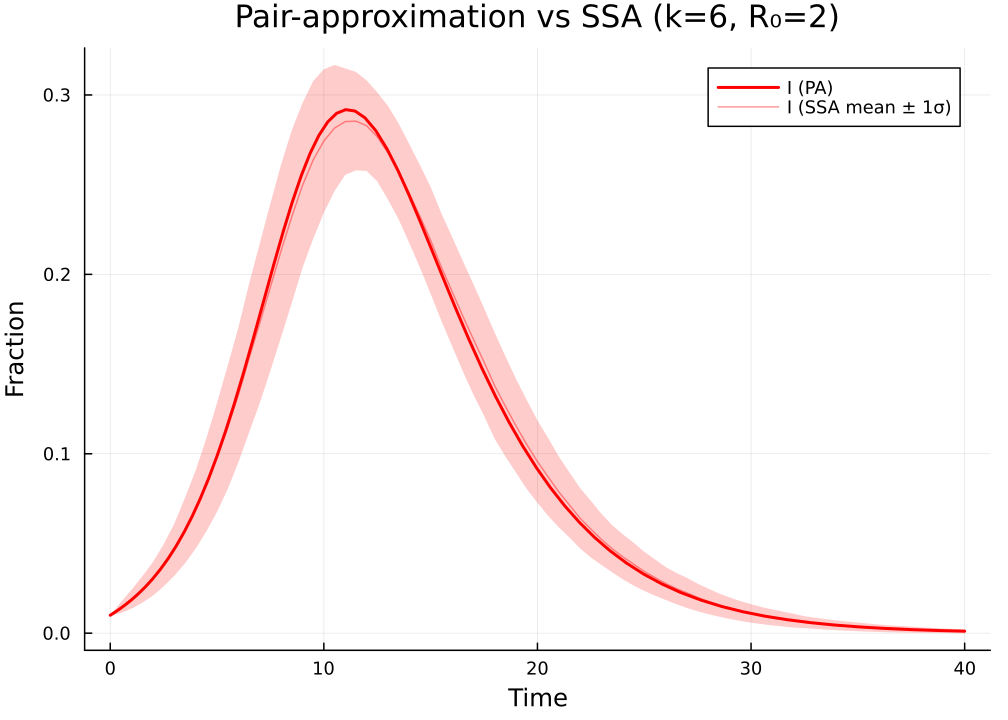

Figure 1: Pair-approximation (lines) vs Gillespie SSA mean ± 1σ ribbons (5 graphs × 40 replicates, N=1000, k=6, R₀=2, ε=0.01).

```julia
p = plot(sol_v.t, sol_v[psys_v.singles[:I]], label = "I (PA)", lw = 2, color = :red,
         xlabel = "Time", ylabel = "Fraction",
         title = "Pair-approximation vs SSA (k=6, R₀=2)")
plot!(p, t_no, μ_no[:I], ribbon = σ_no[:I],
      label = "I (SSA mean ± 1σ)", color = :red,
      fillalpha = 0.2, linealpha = 0.4, lw = 1)
p
```